# Parallel Computing

Felix Taschbach

Maastricht University

## Load Packages

We begin by installing and loading any required packages. The following code first installs the package pacman, if necessary, and then uses pacman to install, if required, and load the packages needed to run this script.

```r
# Clear all variables
rm(list=ls())
options(java.parameters="-Xmx16g") # only necessary for large file imports
# to run this code, you  merely need to set the file path to the sdf file
DATA.PATH = '/Users/felix/Google Drive/Uni/Systems Biology/Year 2/Scientific Programming/scientificProgramming2/aid624202.sdf'
# install pacman if necessary
if (!require("pacman")) suppressPackageStartupMessages(install.packages("pacman"))
```

```r
# install required packages
pacman::p_load("parallel","rcdk","itertools","doParallel")
```

## Import the data

Now, I load the `aid624202.sdf` file and compute the descriptor matrix. As the file is over 1 gb, it is imported using an iterator. The iterator goes through every molecule one by one and adds it to the `mols` list, either until all molecules are imported, or until a pre-set number of molecules is imported.

```r
# the total amount of molecules in the sdf file
max_n <- 377550
# the amount of molecules that will be imported
n <- 1000
# iload.molecules requires the full path
# creates an iterator to import the `aid624202.sdf` file
iter <- iload.molecules(DATA.PATH, type='sdf')
# creates a txtProgressBar object to display the progress of importing the selected molecules
pb <- txtProgressBar(min = 0, max = n, style = 3)
counter <- 0   # initiate counter
mols <- list()   # initiate list to hold the selected molecules
while(hasNext(iter)) {  # runs until
  counter <- counter + 1 # update the counter
  mols[[counter]] <- nextElem(iter)   # save the selected molecule in the list
  setTxtProgressBar(pb, counter)
  if(counter == n){
    break
  }
}
close(pb)
```

## Calculate the molecular descriptors in parallel

Now, I distribute the data among the cores and compute the molecular descriptors of each imported molecule. As we are only interested in the amount of time it takes to calculate the descriptors and not in the descriptors themselves, only the seconds elapsed will be saved. However, I used the function `all.equal()` to verify that the descriptors calculated in parallel and in sequence are identical. Thus, there are the calculation of the different descriptors is threadsafe. A few of the molecules are not correctly parsed and thus lead to a small percentage of wrong molecules with empty smile strings.

```r
# detects the amount of cores of the computer running this script
numCores <- detectCores() - 1
# get a list of all descriptors that will be calculated
descNames <- unique(unlist(sapply(get.desc.categories()[2:4], get.desc.names)))
# initialise progress bar
pb <- txtProgressBar(min = 2, max = numCores, style = 3)
# convert the molecules into smiles
smiles <- lapply(unlist(mols),get.smiles)
# initialise list that will hold the amount of seconds elapsed during each calculation
time <- list()
results <- list()
# returns the seconds elapsed during molecular descriptor calculation for various amounts of cores
for(ncores in 1:numCores){
  cl <- makeCluster(ncores)     # create cluster
  clusterExport(cl,"descNames") # export descriptor names to each core
  clusterExport(cl,"smiles")    # export the molecules as smiles to each core
  clusterEvalQ(cl, pacman::p_load("rcdk")) # load required packages in each core
  registerDoParallel(cl) # make the next foreach call parallel
  time[ncores] <- system.time({foreach(i=1:n,.combine=rbind) %dopar% eval.desc(parse.smiles(smiles[[i]]),descNames,verbose=F)})[3]
  setTxtProgressBar(pb, ncores)
  stopCluster(cl)
}
```

## Finally, I plot the results.

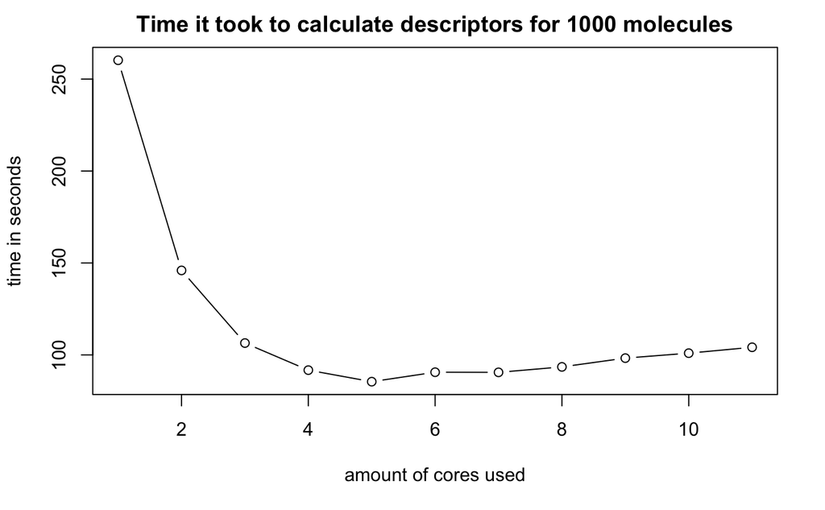

```r
plot(unlist(time),xlab="amount of cores used",ylab="time in seconds",main=paste0("Time it took to calculate descriptors for ",n," molecules"),type='b')
```